# Total polyphenols

Total polyphenols were measured by Amma Agyei using the Folin-Ciocalteau assay Spring of 2019.

# Read in data

Total polyphenols data, leafhopper density data, and leaf damage data

```r
tp <- read_csv(here("data", "raw", "2017 total polyphenols.csv"))
damage <- read_rds(here('data', 'cleaned', '2017_treatment_data.rds'))
```

Join data sheets.

```r
tp2 <-
  tp %>%
  clean_names() %>%
  full_join(damage, by = "sample") %>%
  select(-leaf_density) #identical to `density_end`
tp2
```

| sample | standard_deviation | mean_ga_equivalent | coefficient_of_variation | mg_tea | mg_g_gae | cultivar | mean_leaf_area_px | mean_percent_damage | n_leaves | twister_damage | plant_num | density_treatment | density_start | density_end |
| --- | --- | --- | --- | --- | --- | --- | --- | --- | --- | --- | --- | --- | --- | --- |
| Q1 | 0.005 | 0.141 | 3.6 | 21.2 | 6.650943 | Q | 221981.7 | 3.4539116 | 7 | 2.4087068 | 1 | 2.0 | 2.000000 | 0.7692308 |
| Q2 | 0.002 | 0.144 | 1.5 | 20.3 | 7.093596 | Q | 162558.5 | 13.6630927 | 11 | 1.7977667 | 2 | 1.5 | 1.500000 | 0.3333333 |
| Q4 | 0.021 | 0.120 | 17.1 | 20.5 | 5.853659 | Q | 280913.4 | 7.1812498 | 9 | 2.4001920 | 4 | 1.5 | 1.571429 | 1.1428571 |
| Q5 | 0.025 | 0.149 | 17.1 | 20.1 | 7.412935 | Q | 250368.2 | 5.2467133 | 11 | 0.3022481 | 5 | 2.0 | 2.000000 | 0.9230769 |
| Q6 | 0.020 | 0.155 | 12.9 | 20.2 | 7.673267 | Q | 260359.1 | 1.0004989 | 11 | 0.6598674 | 6 | 1.0 | 1.000000 | 0.5000000 |
| Q7 | 0.010 | 0.138 | 7.1 | 20.7 | 6.666667 | Q | 259698.7 | 0.8653852 | 16 | 0.2836120 | 7 | 0.0 | 0.000000 | 0.0000000 |
| Q8 | 0.008 | 0.137 | 5.9 | 20.4 | 6.715686 | Q | 260752.3 | 0.5655819 | 12 | 0.3923327 | 8 | 0.5 | 0.500000 | 0.1666667 |
| Q9 | 0.005 | 0.157 | 3.3 | 20.6 | 7.621359 | Q | 198261.9 | 2.0338397 | 16 | 0.2586996 | 9 | 0.5 | 0.500000 | 0.2500000 |
| Q10 | 0.019 | 0.121 | 16.1 | 20.8 | 5.817308 | Q | 238889.1 | 2.3432239 | 8 | 0.9025967 | 10 | 1.5 | 1.500000 | 0.1250000 |
| Q11 | 0.005 | 0.166 | 3.1 | 20.7 | 8.019324 | Q | 275033.6 | 1.1012433 | 14 | 0.3033586 | 11 | 0.5 | 0.500000 | 0.3125000 |

[output cut: 9 more lines]

- sample: cultivar and sample ID. Q = qing xin da mao
- standard_deviation: from averaging triplicates
- mean_ga_equivalent: galic acid equivalents in mg/mL (i think)
- coefficient_of_variation: from averaging triplicates(?)
- leaf_density: leafhopper density at end of experiment in insects/young leaf
- mg_tea: mg of tea powder
- mg_g_gae: galic acid equivalents in mg/g of tea powder

These data are means of triplicate runs.

# Regression with leafhopper density as predictor

```r
shapiro.test(tp2$mg_g_gae)
```

```
    Shapiro-Wilk normality test

data:  tp2$mg_g_gae
W = 0.89954, p-value = 0.04773
```

```r
#normal enough
```

I’ll test for a quadratic or linear relationship

```r
dens.poly <- lm(mg_g_gae ~ poly(density_end, 2), data = tp2)
dens.linear <- lm(mg_g_gae ~ density_end, data = tp2)
dens.null <- lm(mg_g_gae ~ 1, data = tp2)
AIC(dens.poly, dens.linear, dens.null)
```

|  | df | AIC |
| --- | --- | --- |
| dens.poly | 4 | 56.25619 |
| dens.linear | 3 | 57.71723 |
| dens.null | 2 | 57.00923 |

```r
# summary(dens.poly)
Anova(dens.poly)
```

```
Anova Table (Type II tests)

Response: mg_g_gae
                      Sum Sq Df F value Pr(>F)
poly(density_end, 2)  4.0084  2  2.2738 0.1352
Residuals            14.1026 16
```

## Polyphenols vs. Density

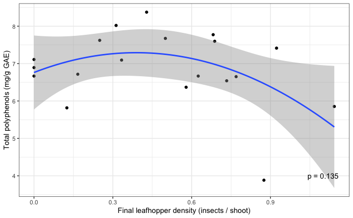

# Relationship between density and damage

Let’s check the relationship between leafhopper density and damage

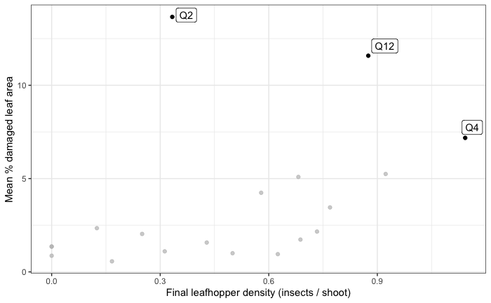

Q2 stands out as extreme. Inspection of the images shows that it includes 3 leaves with heavy hopperburn.

For example:

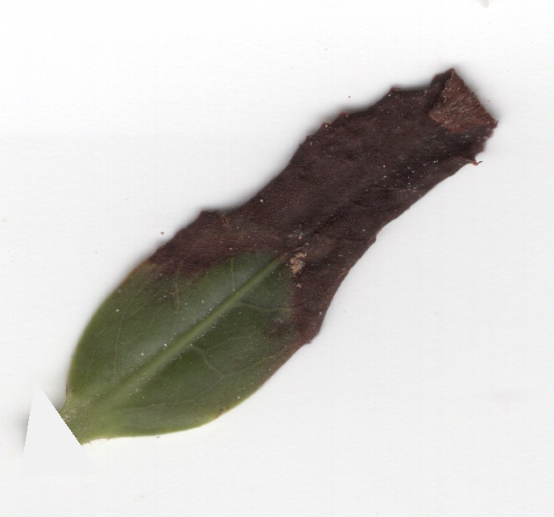

Even without this sample, there is clearly not a perfectly linear relationship between leafhopper density and damage. Using damage as a predictor migh give different results and would also allow me to potentially combine data from multiple years (although I did use a different classifier for the two years…I *could* re-do image analysis using the same classifier, or possibly re-train one on samples from both years.)

# Regression with %damage as predictor

```r
dam.poly <- lm(mg_g_gae ~ poly(mean_percent_damage, 2), data = tp2)
dam.linear <- lm(mg_g_gae ~ mean_percent_damage, data = tp2)
dam.null <- lm(mg_g_gae ~ 1, data = tp2)
AIC(dam.poly, dam.linear, dam.null)
```

|  | df | AIC |
| --- | --- | --- |
| dam.poly | 4 | 56.11519 |
| dam.linear | 3 | 54.32619 |
| dam.null | 2 | 57.00923 |

```r
# summary(dam.linear)
Anova(dam.linear)
```

```
Anova Table (Type II tests)

Response: mg_g_gae
                     Sum Sq Df F value  Pr(>F)
mean_percent_damage  3.9563  1  4.7516 0.04362 *
Residuals           14.1547 17
---
Signif. codes:  0 ‘***’ 0.001 ‘**’ 0.01 ‘*’ 0.05 ‘.’ 0.1 ‘ ’ 1
```

Now, the linear model is the best and there is a marginally significant linear relationship with % damage (p = 0.044)

## Polyphenols vs. Damage

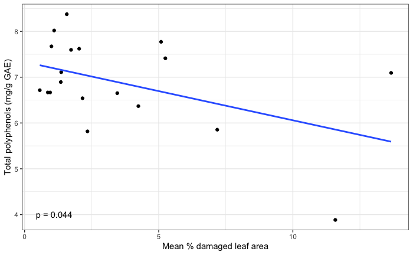

## If I remove sample Q2…

```r
tp3 <- tp2 %>% filter(sample != "Q2")
dam.poly.2 <- lm(mg_g_gae ~ poly(mean_percent_damage, 2), data = tp3)
dam.linear.2 <- lm(mg_g_gae ~ mean_percent_damage, data = tp3)
dam.null.2 <- lm(mg_g_gae ~ 1, data = tp3)
AIC(dam.poly.2, dam.linear.2, dam.null.2)
```

|  | df | AIC |
| --- | --- | --- |
| dam.poly.2 | 4 | 43.92168 |
| dam.linear.2 | 3 | 46.28762 |
| dam.null.2 | 2 | 55.14475 |

```r
# summary(dam.poly.2)
Anova(dam.poly.2)
```

```
Anova Table (Type II tests)

Response: mg_g_gae
                              Sum Sq Df F value   Pr(>F)
poly(mean_percent_damage, 2) 10.3096  2  9.9725 0.001759 **
Residuals                     7.7535 15
---
Signif. codes:  0 ‘***’ 0.001 ‘**’ 0.01 ‘*’ 0.05 ‘.’ 0.1 ‘ ’ 1
```

```r
# Anova(dam.linear.2)
```

Then polynomial model is best and highly significant (the linear model is also highly significant) (p = 0.002

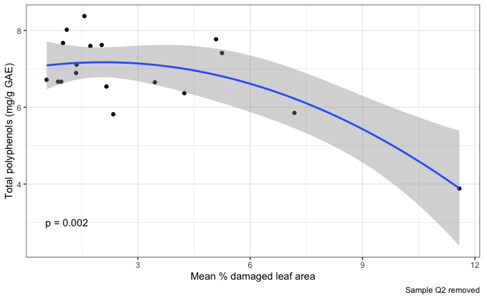